# Your Digest for Monday, Jul 10, 2023 11:59 PM

> Angiotensin I then is converted to angiotensin II in the lungs and kidneys by angiotensin-converting enzymes (ACE). Angiotensin II is an octapeptide that is activated by type-1, G protein-coupled angiotensin II receptors. These receptors have different functions depending on the types of cells that contain the receptor. *However, it has five primary functions that include: increasing aldosterone, increasing sodium-hydrogen exchange within the proximal renal tubule, increasing thirst drive within the hypothalamus, increasing antidiuretic hormone, and acting on G protein-coupled receptors that activate IP3/Ca2+ second messenger systems within arterioles to cause vasoconstriction*. Aldosterone then undergoes its actions within the kidney.

> [!INFO] Clinical presentation of DM nephropathy  
> most common clinical abnormalities of diabetic kidney disease
> 1. are persistent albuminuria
> 2. and / or (eGFR)

(These are more clearly seen in type I DM. In type 2 DM, vascular and tubuluinterstitial changes predominate.)

```
 Also, renal autoregulation of blood flow may be impaired - exposing the kidney to effects of hypertension. => increased GFR
```

Oxidative stress and inlammation

Symptomatic management: Propronolol for beta blockade.  
Methimazole is active metabolite of carbimazole; Equivalent dose of *carbimazole is 40% higher*.

> [!TIP] C --> M: Alphabetical order

> hepa**T**ic Failure

#2022BSQ Q16

| Carbimazole / methimazole | Propylthiouracil |
| --- | --- |
| Less severe side effects. Usually first line choice | Usually second line, **except T1 of pregnancy**, and thyroid storm |
|  | Blocks 5'-monodeiodinase, which converts peripheral T4 to T3 conversion |
|  | Less frequent teratogenic effects |
| Pruritus, rash, arthritis, urticaria, abnormal taste | Same |
| **Agranulocytosis (0.1% incidence)** | **Same** |
| Less risk of hepatic injury | **Fulminant hepatic failure** |
|  | ANCA positive vasculitis |

> [!TIP] Pharmacokinetics of carbimazole / methimazole are generally better than PTU.  
> Carb/methimazole has longer half life.  
> High intrathyroidal concentrations, outlasting the plasma half life.  
> More inhibition of iodine organification.

Rash: Usually can be treated with antihistamine, stoppage of thionamide not required. Cross reactivity to different thionamide seen in 50%.

**Agranulocytosis**:  
Thionamides have a high risk of agranulocytosis compared to other drugs that cuase it.  
Agranulocytosis occurs within *2-3 months* of start of treatment.  
If it occurs, treatment with thionamides is contraindicated.

# Table of inheritances

#2022BSQ Q19

1. [[table_of_genetic_disorders.pdf]]
2. [[TABLE-of-GENETIC-DISORDERS.pdf]]

> The albumin excretion rate can be estimated (using spot, or random, urine measurements of albumin and creatinine and calculating the albumin-to-creatinine ratio), or it can be measured (using a 24-hour urine collection).

See also [[Neurology Miscellaneous#Subarachnoid space|Sub-arachnoid space]]

## Blood brain barrier

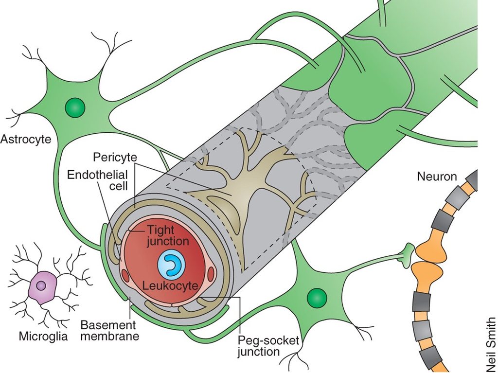

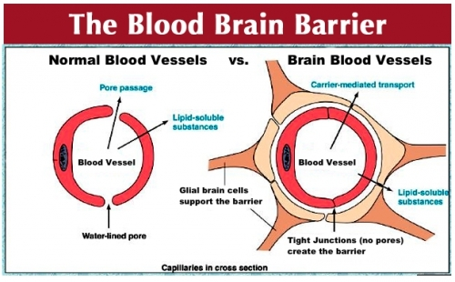

## Subarachnoid space

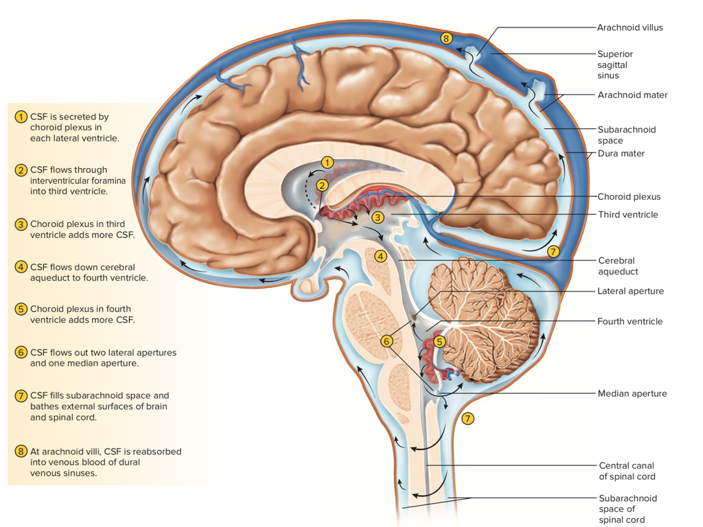

Hemodynamically mediated AKI due to NSAIDs occurs via attenuation of PG-mediated renal vasodilation. In healthy patients, PGs play little role in renal hemodynamics.

## Calculating drug doses

[Epic article by DeragedPhysiology](https://derangedphysiology.com/main/cicm-primary-exam/required-reading/pharmacokinetics/Chapter%204.0.1/maintenance-dose-and-loading-dose)  
#2022BSQ Q17

### Loading dose

Given when time-to-steady-state (4-5 half lives) would be too long to wait for the drug to take action.
$$Loading Dose = \frac{{Vd}\times{Tc}}{F}$$
Vd = volume of distribution, Tc = Target concentration, F = bioavailability

### Dose rate and maintenance dose

> For IV drugs given by infusion,
> - **Dose rate** (mg/hr) = dose (mg) divided by dosing interval (hrs)
> - **Maintenance dose rate** (mg/hr) = desired peak concentration (mg/L) × clearance (L/hr)
> - **Loading dose** = desired peak concentration (mg/L) × volume of distribution (L)

> For drugs **not** given IV, these doses need to be divided by the **bioavailability**.

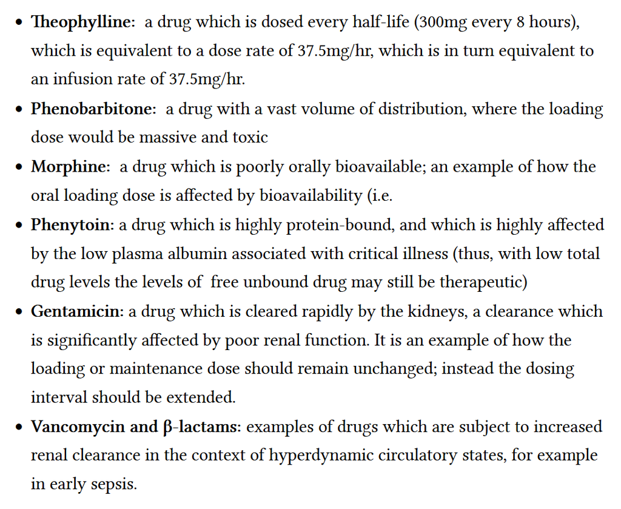

## Therapeutic index

[figure not shown]

# Chronic steroid use

## Side effects

| Synthetic corticosteroid | Natural |
| --- | --- |
| Predni and Methyl predni |  |
| Dexamethasone |  |
| betamethasone |  |
| Triamcinolone |  |
| **Little mineralocorticoid or andro/estrogenic activity** |  |
| Therefore, they suppress HPA axis and Cause cushing |  |
| **Mainly glucocorticoid activity** |  |

1. HPA Axis - glucocorticoids suppress **CRH** and **ACTH.**
2. Cushings

clinically desirable effects of steroids appear to result primarily from transrepression, which results in the decreased production of proinflammatory proteins

> [!INFO] Glucocorticoids have non-genomic effects as well  
> "Nongenomic effects of glucocorticoids include rapid, nonspecific interactions of glucocorticoids with cellular membranes, nongenomic effects medicated by cytosolic glucocorticoid receptors, and specific interactions with membrane-bound glucocorticoid receptors"

> [!INFO] Irriversible side effects  
> With the exception of **cataracts**, a potential acceleration in **atherosclerotic vascular disease**, and bone effects (**osteoporosis and osteonecrosis**), all glucocorticoid toxicity is at least partially reversible over time with glucocorticoid discontinuation

### Other side effects of steroid

1. Cushingoid features - *Redistrubition of fat*, coupled with **weight gain due to increased appetite.**
2. Ophthalmologic effects - cataract (usually bilateral and distinct from age related cataract) and glaucoma and rarely exophtlamos
3. Cardiovascular
   1. Fluid retention and hypertension - particularly at *high* doses.
   2. In healthy individuals, fluid retention is counteracted by "*aldosterone escape mechanism*"

      > Pathologi Increase in aldoesterone can cause salt and water rentention. But after a few days (or about 3Kg gain in weight), diuresis occurs. This is in response to
      > 1. increased ANP secretion
      > 2. Pressure natriuresis - kidney decreases Na resorption in response to increased perfusion pressure
      > 3. Decreased DCT resorption of Na via downregulation of thiaizide sensitive sodium chloride co transported
      3. Increased rate of progression of atherosclerosis and increased risk of ACS and stroke
      4. Increased risk of AF and Atrial flutter
4. Gastric - ulcers, perforations, hepatic steatosis
5. Bone - osteoporosis and osteonecrosis [[Hormone Physiology#Regulation of bone formation and resorption]]
   1. Glucocorticoids increase resorption and decrease formation by binding to receptors in the bone cells.
6. Myopathy - *uncommon*; painless proximal myopathy
7. Neuropsychiatrics - mood disorders, psychosis, memory impairement
8. Metabolic
   1. Hyperglycemia -
   2. including *augmentation of hepatic gluconeogenesis*, *inhibition of glucose uptake in adipose tissue*, and alteration of receptor and postreceptor functions
9. Immune - predisposition to infection
10. Haematologic - neutrophil leukocytosis <- decreased adhesion of neutrophils to the vessel walls. (?something to do with neutrophil rolling and adhesion in acute inflammation?)

# Complications of tuberculosis

#TODO

# Extrapulmonary TB

Occurs either with

1. progressive primary infection
   1. TB bacilli are normally contained by granuloma formation. Granulomas can heal.
   2. Failure to heal causes **progressive primary disease**.
   3. This is usually due to something causing suppression of *cell mediated immunity*.
2. Reactivation of latent infections.

Common sites are the **most vascular organs**;

1. Liver
2. Spleen
3. Bone marrow
4. Brain
5. Kidneys - renal TB

### CNS Tuberculosis

In areas with high prevalence of post primary dissemination of TB, CNS involvement is common.  
Forms of central nervous system (CNS) infection due to *Mycobacterium tuberculosis* include:

1. meningitis,
2. tuberculoma
   1. conglomerate granulomatous focus that develop from **coalescing tubercles** acquired during disseminated bacillemia
3. spinal arachnoiditis,
   1. > Breakdown of granulomatous foci within the spinal cord or meninges -> spinal cord and nerve roots are encased in tuberculous exudates.
   2. Present with feature of root + cord compression
4. and transverse myelitis.
   1. Transverse - entire cross section of the spinal cord is involved.

#### Tuberculous meningitis

The most severe form of extrapulmonary TB.

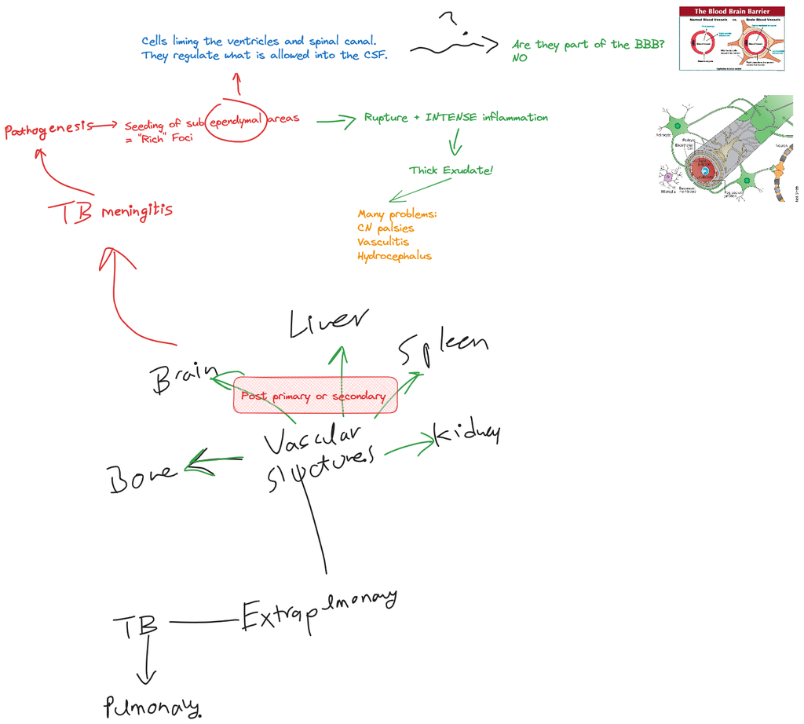

Vasculitis produced by the exudate can cause obliterative endarteritis. This can cause infarctions in the deep structures of the brain.  
eg. Thalamus, basal ganglia, internal capsule.  
Exudate is seen at the base of the brain.